# 260-2016-11-18

2016-11-18 10:06:25

## Today's topic

- Measuring the speed of nervous system conduction
- And a tiny lesson in open, transparent, reproducible data science

## Scheme

- Speed = Distance/Time
- Chain of participants to make distance larger

## Condition 1 (ankle)

- Squeeze ankle
- ankle_shoulder + shoulder_brain + brain_decide + brain_shoulder + shoulder_hand

## Condition 2 (shoulder)

- Squeeze shoulder
- shoulder_brain + brain_decide + brain_shoulder + shoulder_hand
- Condition 1 - Condition 2
- ankle_shoulder + shoulder_brain + brain_decide + brain_shoulder + shoulder_hand

## Measure

- sum(ankle_shoulder) for all participants -> Distance
- mean(time(Condition 1)) - mean(time(Condtion 2)) -> Time
- Speed = Distance/Time

## Materials

- Stop watch
- Tape measure

## Decisions

- Same hand or dominant?
- Alternate ankle/shoulder or one condition before the other?
- How many trials?
  - Fixed number?
  - When reach asymptote?

## Data files

- Data file with body measurements: ankleshoulder.csv
  - participant, ankleshoulder (cm)
- Data file with reaction times: time.csv
  - trial {1…n}, condition {ankle, shoulder}, time (s)

## Measuring distance

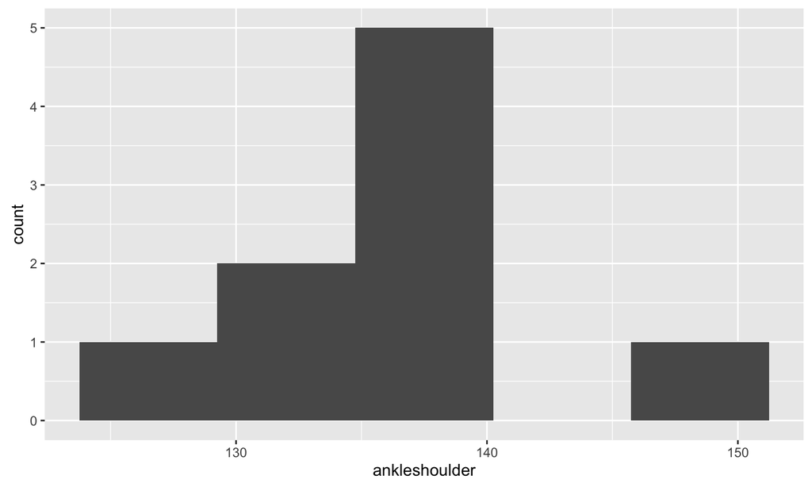

```r
distance = read.csv("csv/ankleshoulder.csv", header = TRUE)

# load Gilmore's favorite plotting, analysis libraries
library(ggplot2)
library(dplyr)
dist.hist = ggplot(data = distance, aes(x=ankleshoulder)) +
  geom_histogram(bins = 5)
```

## Sum distance

```r
with(distance, summary(ankleshoulder))
```

```
##    Min. 1st Qu.  Median    Mean 3rd Qu.    Max.
##   126.0   133.0   135.0   135.1   136.0   148.0
```

```r
# Calculate sum
dist.sum = with(distance, sum(ankleshoulder))
```

The total distance is 1216 cm.

## Measuring time

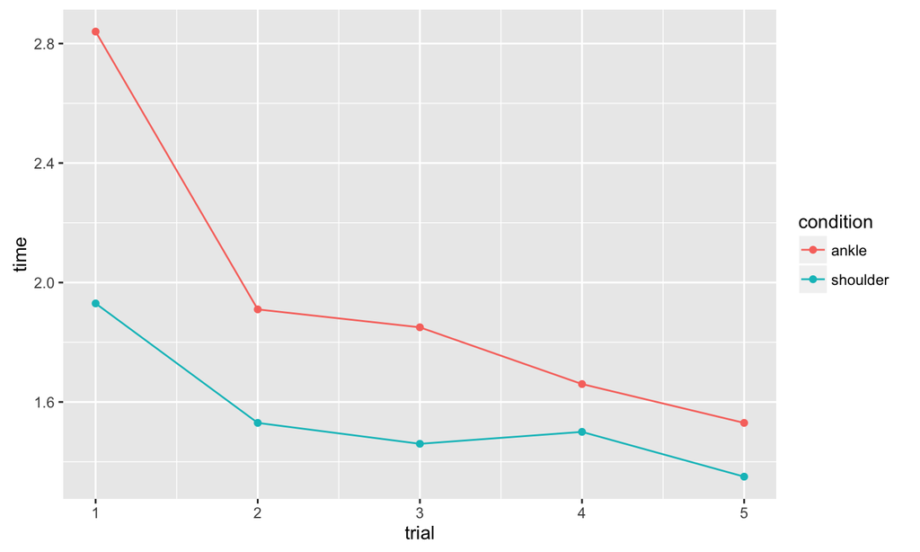

```r
time = read.csv("csv/time.csv", header=TRUE)


# Plot data
time.plot = ggplot(data = time, aes(x=trial, y=time, color=condition)) +
  geom_point() +
  geom_line()
```

## Calculate time difference

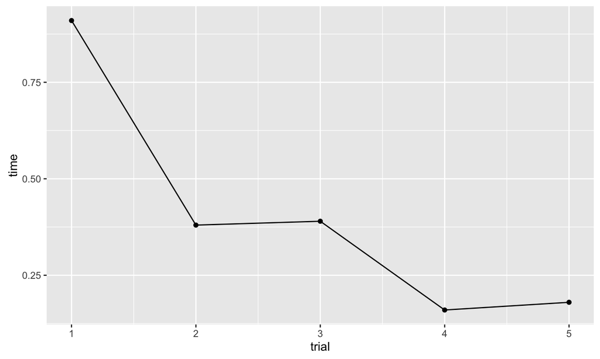

```r
time %>% filter(condition == "ankle") -> ankle.times
time %>% filter(condition == "shoulder") -> shoulder.times

time.diff = data_frame(trial=unique(time$trial), time=ankle.times$time - shoulder.times$time)

time.diff.plot = ggplot(data = time.diff, aes(x=trial, y=time)) +
  geom_point() +
  geom_line()
```

## Calculating speed

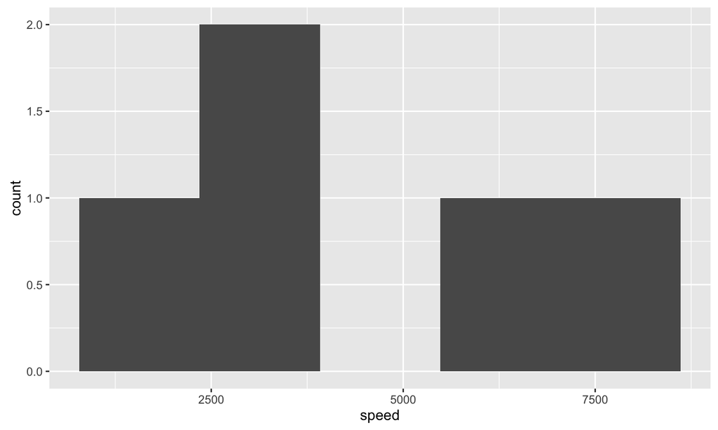

```r
time.diff$speed = dist.sum/time.diff$time

speed.hist = ggplot(data = time.diff, aes(x=speed)) +
  geom_histogram(bins = 5)
```

## Plot time series of speeds

```r
speed.plot = ggplot(data = time.diff, aes(x=trial, y=speed)) +
  geom_point() +
  geom_line()
```

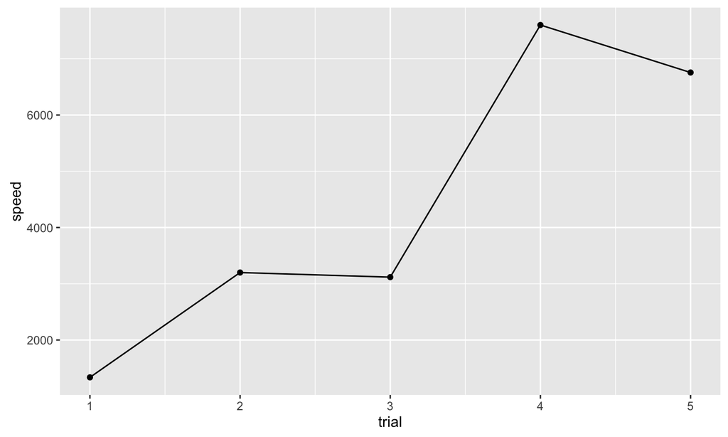

```r
speed.plot
```

## Summarizing findings

- We tested the mean speed of neural propagation in a sample of n=9 college-age adults.
- The mean speed of neural propagation over 5 trials was 44.02 m/s with a range of [13.36, 76] m/s.
- These findings are generally in accord with values we would expect from the literature.